# Introduction to ggplot: course code

### 4.3.3 GDP is squished together on the left, let’s change the axes.

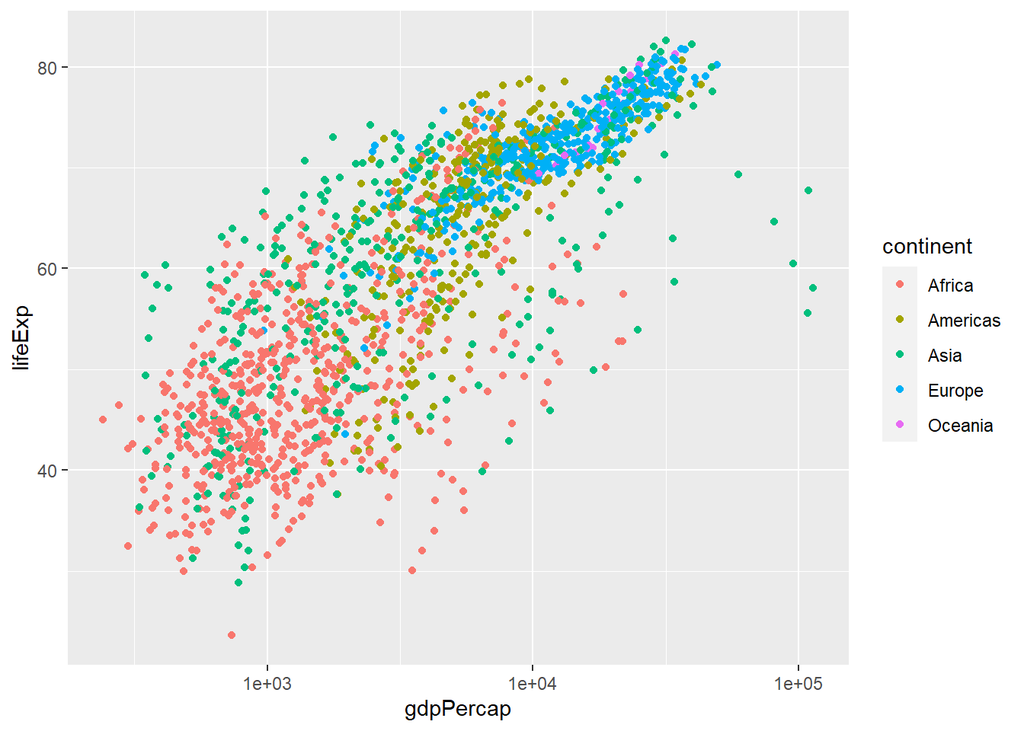

```r
ggplot(gapminder,
  aes(x = gdpPercap,
      y = lifeExp,
      color = continent)) +
  geom_point() +
  scale_x_log10() #<<
```

### 4.3.4 Still lots of overlap in the countries…

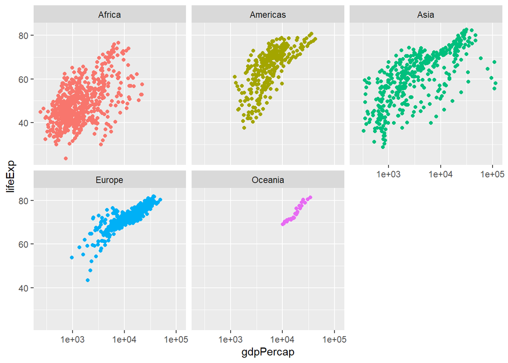

```r
ggplot(gapminder,
  aes(x = gdpPercap,
      y = lifeExp,
      color = continent)) +
  geom_point() +
  scale_x_log10() +
  facet_wrap(~ continent) + #<<
  guides(color = FALSE)     #<<
```

No need for color legend thanks to facet titles

### 4.3.5 Lots of overplotting due to point size, let’s make the points smaller

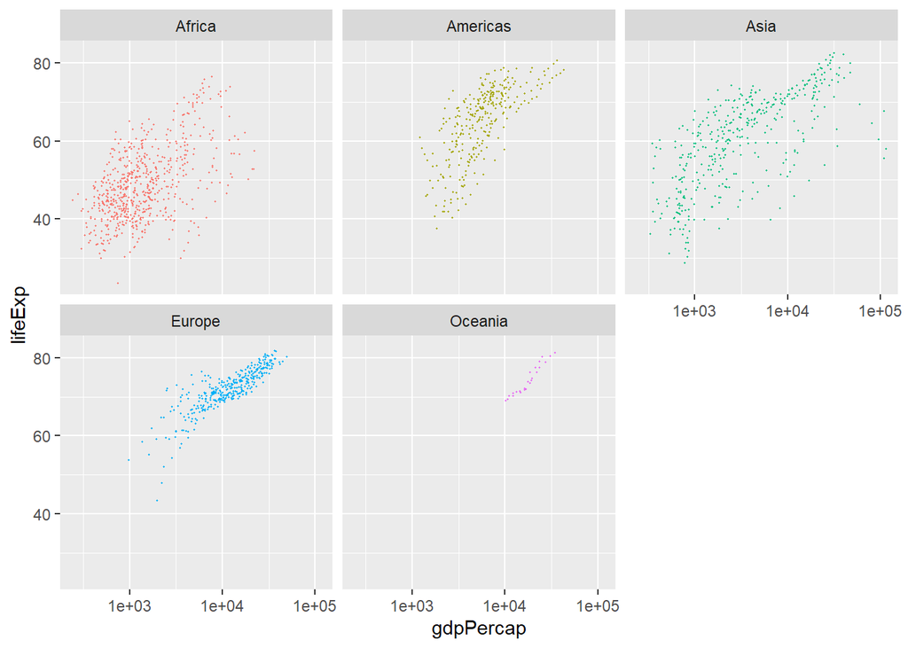

```r
ggplot(gapminder,
  aes(x = gdpPercap,
      y = lifeExp,
      color = continent)) +
  geom_point(size = 0.25) + #<<
  scale_x_log10() +
  facet_wrap(~ continent) +
  guides(color = FALSE)
```

Is there a trend?

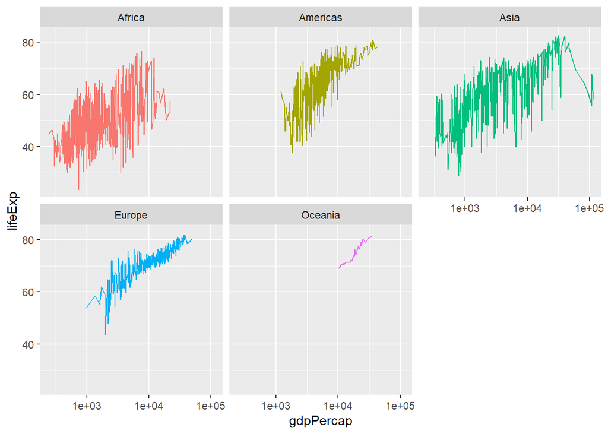

```r
ggplot(gapminder,
  aes(x = gdpPercap,
      y = lifeExp,
      color = continent)) +
  geom_line() + #<<
  #geom_point(size = 0.25) +
  scale_x_log10() +
  facet_wrap(~ continent) +
  guides(color = FALSE)
```

Okay, that line just connected all of the points sequentially…

### 4.3.6 Let’s add the group as an aesthetic to `geom_line()`

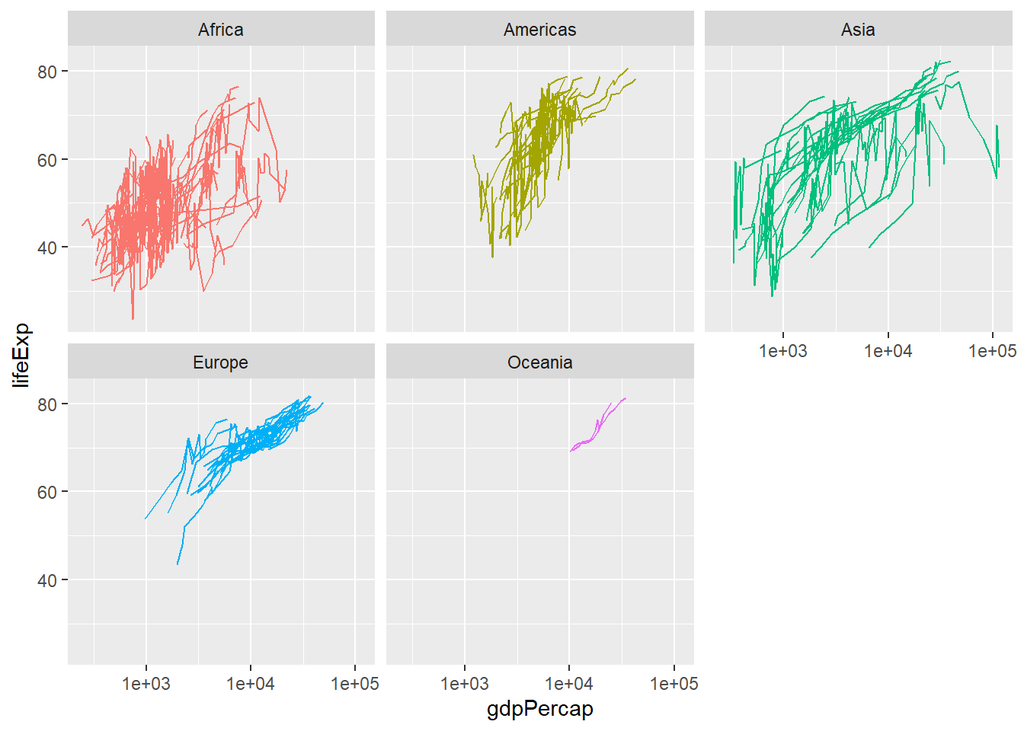

```r
ggplot(gapminder,
  aes(x = gdpPercap,
      y = lifeExp,
      color = continent)) +
  geom_line(
    aes(group = country) #<<
    ) +
  #geom_point(size = 0.25) +
  scale_x_log10() +
  facet_wrap(~ continent) +
  guides(color = FALSE)
```

### 4.3.7 Let’s put year on the x-axis to look at the time series.

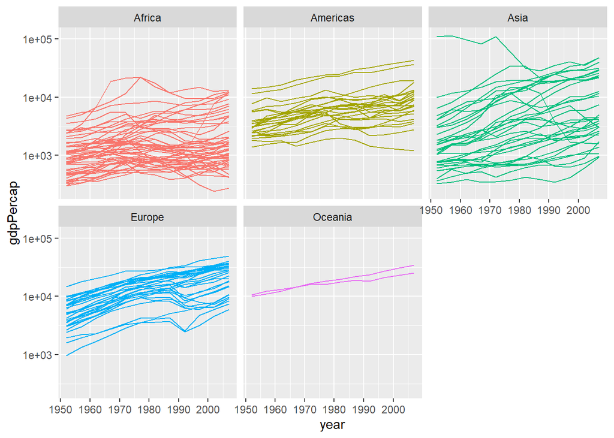

```r
ggplot(gapminder,
  aes(x = year, #<<
      y = gdpPercap, #<<
      color = continent)) +
  geom_line(
    aes(group = country)) +
  #geom_point(size = 0.25) +
  scale_y_log10() + #<<
  facet_wrap(~ continent) +
  guides(color = FALSE)
```

### 4.3.8 Can’t see x-axis labels, let’s change the x axis

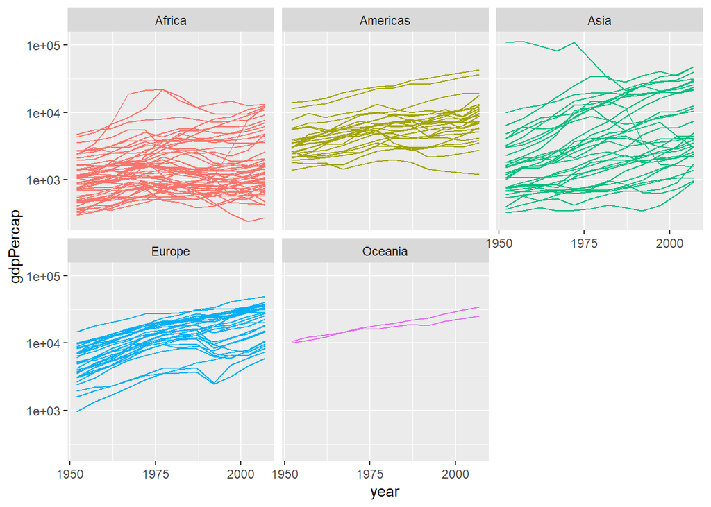

```r
ggplot(gapminder,
  aes(x = year,
      y = gdpPercap,
      color = continent)) +
  geom_line(
    aes(group = country)) +
  #geom_point(size = 0.25) +
  scale_y_log10() +
  scale_x_continuous(breaks = #<<
    seq(1950, 2000, 25) #<<
  ) +                            #<<
  facet_wrap(~ continent) +
  guides(color = FALSE)
```

### 4.3.9 What about life expectancy?

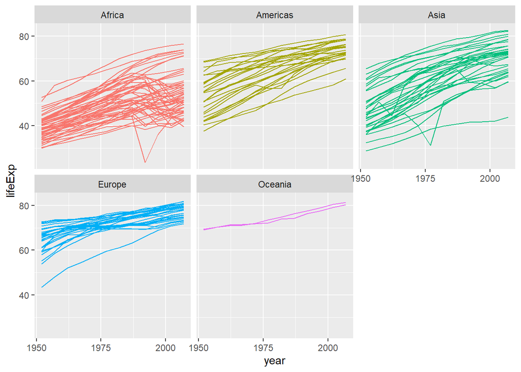

```r
ggplot(gapminder,
  aes(x = year,
      y = lifeExp, #<<
      color = continent)) +
  geom_line(
    aes(group = country)) +
  #geom_point(size = 0.25) +
  #scale_y_log10() + #<<
  scale_x_continuous(breaks =
    seq(1950, 2000, 25)) +
  facet_wrap(~ continent) +
  guides(color = FALSE)
```

Okay, let’s add a trend line

### 4.3.10 Adding a trendline with geom_smooth()

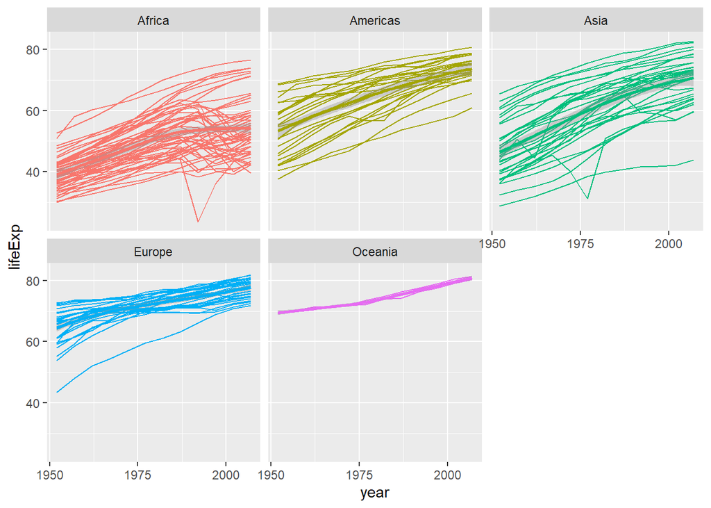

```r
ggplot(gapminder,
  aes(x = year,
      y = lifeExp,
      color = continent)) +
  geom_line(
    aes(group = country)) +
  # geom_point(size = 0.25) +
  geom_smooth() + #<<
  scale_x_continuous(breaks =
    seq(1950, 2000, 25)) +
  facet_wrap(~ continent) +
  guides(color = FALSE)
```

### 4.3.11 De-emphasize individual countries using alpha

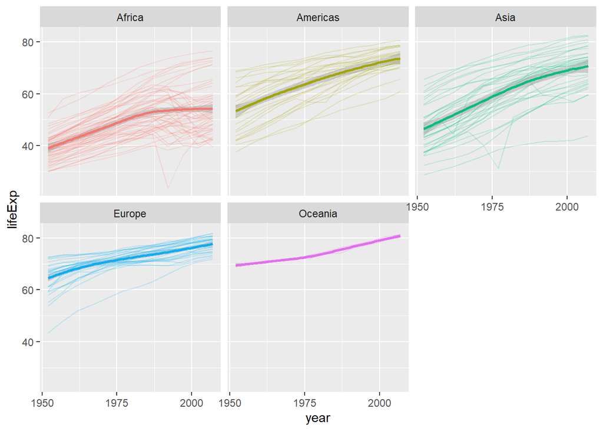

```r
ggplot(gapminder,
  aes(x = year,
      y = lifeExp,
      color = continent)) +
  geom_line(
    aes(group = country),
    alpha = 0.2) + #<<
  #geom_point(size = 0.25) +
  geom_smooth() +
  scale_x_continuous(breaks =
    seq(1950, 2000, 25)) +
  facet_wrap(~ continent) +
  guides(color = FALSE)
```